# office

Sherry Hu

5/19/2020

```r
# libraries
library(car)
library(olsrr)
library(schrute)
library(tibble)
library(forcats)
library(dplyr)
```

```r
library(ggplot2)
library(tidytext)
library(stringr)
library(textdata)
library(tidyr)
```

```r
# load in data
transcripts <- schrute::theoffice
head(transcripts)
```

```
## # A tibble: 6 x 12
##   index season episode episode_name director writer character text
##   <int>  <int>   <int> <chr>        <chr>    <chr>  <chr>     <chr>
## 1     1      1       1 Pilot        Ken Kwa… Ricky… Michael   All …
## 2     2      1       1 Pilot        Ken Kwa… Ricky… Jim       Oh, …
## 3     3      1       1 Pilot        Ken Kwa… Ricky… Michael   So y…
## 4     4      1       1 Pilot        Ken Kwa… Ricky… Jim       Actu…
## 5     5      1       1 Pilot        Ken Kwa… Ricky… Michael   All …
## 6     6      1       1 Pilot        Ken Kwa… Ricky… Michael   Yes,…
## # … with 4 more variables: text_w_direction <chr>, imdb_rating <dbl>,
## #   total_votes <int>, air_date <fct>
```

```r
ratings <- readr::read_csv('https://raw.githubusercontent.com/rfordatascience/tidytuesday/master/data/2020/2020-03-17/office_ratings.csv')
head(ratings)
```

```
## # A tibble: 6 x 6
##   season episode title         imdb_rating total_votes air_date
##    <dbl>   <dbl> <chr>               <dbl>       <dbl> <date>
## 1      1       1 Pilot                 7.6        3706 2005-03-24
## 2      1       2 Diversity Day         8.3        3566 2005-03-29
## 3      1       3 Health Care           7.9        2983 2005-04-05
## 4      1       4 The Alliance          8.1        2886 2005-04-12
## 5      1       5 Basketball            8.4        3179 2005-04-19
## 6      1       6 Hot Girl              7.8        2852 2005-04-26
```

```r
nrow(transcripts)
```

```
## [1] 55130
```

- There are 55,130 lines said in all 9 seasons of The Office.

```r
# make season and episode factors
# remove "" for parsing issues
transcripts %>%
  mutate(season = as.integer(season),
         episode = as.integer(episode)) %>%
  mutate(character = str_remove_all(character, '"'))
```

```
## # A tibble: 55,130 x 12
##    index season episode episode_name director writer character text
##    <int>  <int>   <int> <chr>        <chr>    <chr>  <chr>     <chr>
##  1     1      1       1 Pilot        Ken Kwa… Ricky… Michael   All …
##  2     2      1       1 Pilot        Ken Kwa… Ricky… Jim       Oh, …
##  3     3      1       1 Pilot        Ken Kwa… Ricky… Michael   So y…
##  4     4      1       1 Pilot        Ken Kwa… Ricky… Jim       Actu…
##  5     5      1       1 Pilot        Ken Kwa… Ricky… Michael   All …
##  6     6      1       1 Pilot        Ken Kwa… Ricky… Michael   Yes,…
##  7     7      1       1 Pilot        Ken Kwa… Ricky… Michael   I've…
##  8     8      1       1 Pilot        Ken Kwa… Ricky… Pam       Well…
##  9     9      1       1 Pilot        Ken Kwa… Ricky… Michael   If y…
## 10    10      1       1 Pilot        Ken Kwa… Ricky… Pam       What?
## # … with 55,120 more rows, and 4 more variables: text_w_direction <chr>,
## #   imdb_rating <dbl>, total_votes <int>, air_date <fct>
```

# EDA

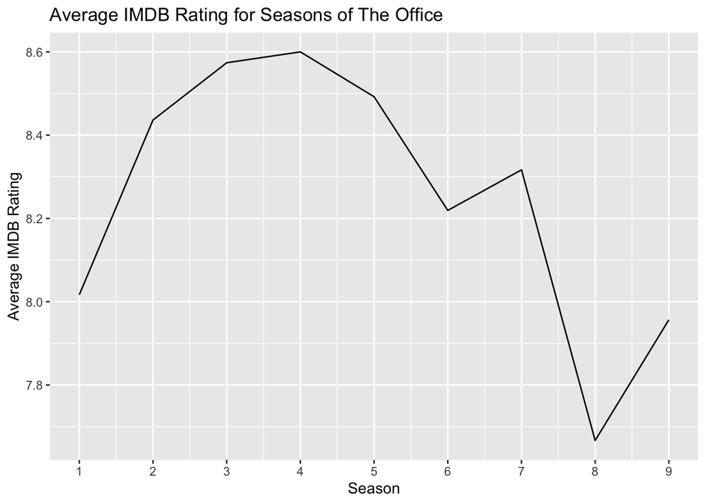

```r
# average rating across 9 seasons
ratings %>%
  group_by(season) %>%
  summarise(avg_rating = mean(imdb_rating)) %>%
  ggplot(aes(season, avg_rating)) +
  geom_line() +
  scale_x_continuous(breaks =1:9) +
  ggtitle("Average IMDB Rating for Seasons of The Office") +
  xlab("Season") + ylab("Average IMDB Rating")
```

- We see a huge dip in average rating after season 7. An initial hunch is that this is due to Steve Carell (Michael Scott), the main character, leaving this season.

[figure not shown]

```r
# ratings by episode
ratings %>%
  mutate(title = fct_inorder(title),
         episode_number = row_number()) %>%
  ggplot(aes(episode_number, imdb_rating)) +
  geom_line(group = 1) +
  geom_point(aes(color = factor(season))) +
  expand_limits(x = -8) +
  geom_smooth(group = 1) +
  theme(axis.text.x = element_blank(), panel.grid.major.x = element_blank()) +
  labs(x = "Episode number",
       y = "IMDB Rating",
       title = "Popularity of The Office episodes over time",
       subtitle = "Color represents season, size represents number of ratings")
```

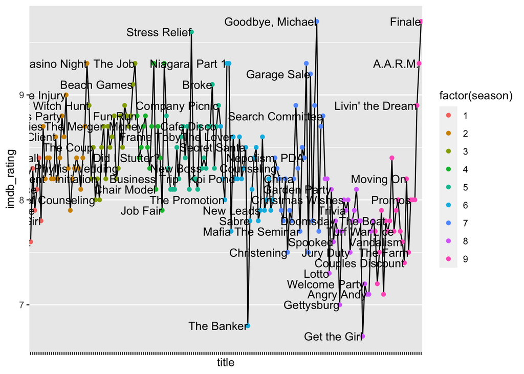

```r
# ratings by episode w/ labels
ratings %>%
  mutate(title = fct_inorder(title)) %>%
  ggplot(aes(title, imdb_rating)) +
  geom_line(group = 1) +
  geom_point(aes(color = factor(season))) +
  geom_text(aes(label = title), check_overlap = TRUE, hjust = 1) +
  theme(axis.text.x = element_blank(), panel.grid.major.x = element_blank())
```

- This shows us ratings by episode. We note that the finale has the highest rating. The episode with the second highest rating is “Goodbye Michael”, which was the last episode Carell was in.

```r
# Looking at how many lines each character has
transcripts %>% count(character, sort = TRUE)
```

```
## # A tibble: 773 x 2
##    character     n
##    <chr>     <int>
##  1 Michael   10921
##  2 Dwight     6847
##  3 Jim        6303
##  4 Pam        5031
##  5 Andy       3754
##  6 Angela     1569
##  7 Kevin      1564
##  8 Erin       1440
##  9 Oscar      1368
## 10 Ryan       1198
## # … with 763 more rows
```

- Michael has the most lines across all seasons, followed by Dwight, Jim, and Pam. From this, we can get a slight sense of who the main characters are.
- Note that Creed, who only says 396 lines across all seasons, is a character that is loved by a lot of people. Thus, when selecting characters, it may not be the best idea to just select the characters who say the most number of lines.

```r
unique(sort(transcripts$character))
```

```
##   [1] "\"Angela\""                        "\"Jim\""
##   [3] "\"Jo\""                            "\"Phyllis\""
##   [5] "(Pam's mom) Heleen"                "3rd Athlead Employee"
##   [7] "4th Athlead Employee"              "A.J."
##   [9] "Aaron Rodgers"                     "Abby"
##  [11] "abe"                               "Actor"
##  [13] "Actress"                           "Ad guy 1"
##  [15] "Ad guy 2"                          "AJ"
##  [17] "Alan"                              "Albiny"
##  [19] "Alex"                              "Alice"
##  [21] "All"                               "All but Oscar"
##  [23] "All Girls"                         "All the Men"
##  [25] "Alonzo"                            "Amanda"
##  [27] "Amy"                               "Andy"
##  [29] "Andy & Erin"                       "Andy & Michael"
```

[output cut: 372 more lines]

- Let’s look at what characters are in the data. From the above list, we see that there are a lot of errors in spelling. For example, “Michael” and “Micahel” refer to the same character. We attempt to fix this to the best of our ability.

```r
# fixing Michael errors
transcripts$character[transcripts$character == "Micahel"] <- "Michael"
transcripts$character[transcripts$character == "Micael"] <- "Michael"
transcripts$character[transcripts$character == "Michae"] <- "Michael"
transcripts$character[transcripts$character == "Mihael"] <- "Michael"
transcripts$character[transcripts$character == "Miichael"] <- "Michael"
transcripts$character[transcripts$character == "Micheal"] <- "Michael"
transcripts$character[transcripts$character == "Michal"] <- "Michael"
transcripts$character[transcripts$character == "Michel"] <- "Michael"
transcripts$character[transcripts$character == "Michael "] <- "Michael"
transcripts$character[transcripts$character == "MIchael"] <- "Michael"
transcripts$character[transcripts$character == "M ichael"] <- "Michael"

# fixing Pam errors
transcripts$character[transcripts$character == "Pam "] <- "Pam"

# fixing Jim errors
transcripts$character[transcripts$character == "JIm"] <- "Jim"
transcripts$character[transcripts$character == "Jim "] <- "Jim"

# fixing Dwight errors
transcripts$character[transcripts$character == "Dwight "] <- "Dwight"
transcripts$character[transcripts$character == "Dwight."] <- "Dwight"
transcripts$character[transcripts$character == "DwightKSchrute"] <- "Dwight"

# fixing Angela errors
transcripts$character[transcripts$character == "\"Angela\""] <- "Angela"
transcripts$character[transcripts$character == "Anglea"] <- "Angela"
transcripts$character[transcripts$character == "Angel"] <- "Angela"
transcripts$character[transcripts$character == "Angels"] <- "Angela"

# fixing Ryan errors
transcripts$character[transcripts$character == "Ryan Howard"] <- "Ryan"

# fixing Andy errors
transcripts$character[transcripts$character == "sAndy"] <- "Andy"

# fixing Robert California errors
# transcripts$character[transcripts$character == "Robert"] <- "Robert California"

# fixing Stanley errors
transcripts$character[transcripts$character == "Stanely"] <- "Stanley"

# fixing Meredith errors
transcripts$character[transcripts$character == "Meridith"] <- "Meredith"

# fixing Darryl errors
transcripts$character[transcripts$character ==  "Darrly"] <- "Darryl"
transcripts$character[transcripts$character ==  "Darry"] <- "Darryl"
transcripts$character[transcripts$character ==  "Daryl"] <- "Darryl"

# fixing Phyllis errors
transcripts$character[transcripts$character ==  "Phylis"] <- "Phyllis"
transcripts$character[transcripts$character ==  "Phyliss"] <- "Phyllis"

# fixing Holly errors
transcripts$character[transcripts$character ==  "Holy"] <- "Holly"

# fixing Todd Packer errors
transcripts$character[transcripts$character ==  "Sweeney Todd"] <- "Todd Packer"
transcripts$character[transcripts$character ==  "Todd"] <- "Todd Packer"

# fixing David Wallace errors
transcripts$character[transcripts$character ==  "David Wallcve"] <- "David Wallace"
transcripts$character[transcripts$character ==  "Dacvid Walalce"] <- "David Wallace"
transcripts$character[transcripts$character ==  "Dacvid Wallace"] <- "David Wallace"

# fixing Bob Vance errors
transcripts$character[transcripts$character ==  "Bob"] <- "Bob Vance"
transcripts$character[transcripts$character ==  "Bob Vance, Vance Refrigeration"] <- "Bob Vance"

# Character personalities stay consistent whether or not they're on the phone
transcripts$character[transcripts$character == "Michael [on phone]" ] <- "Michael"
transcripts$character[transcripts$character == "Pam [on phone]"] <- "Pam"
transcripts$character[transcripts$character ==  "Jan [on phone]"] <- "Jan"
transcripts$character[transcripts$character == "Dwight [on phone]"] <- "Dwight"

# D is mapped to Dwight because it's his nickname
transcripts$character[transcripts$character == "D"] <- "Dwight"
```

- Next, we would like to drop some characters. As shown above, filtering characters by the number of lines said may not be the best idea. Instead, we only keep characters who are listed as “Main Characters” or “Supporting Characters” on this official wiki page for The Office: https://theoffice.fandom.com/wiki/Main_Characters.

```r
# list of characters we want
included_characters <- c("Michael", "Dwight", "Jim", "Pam", "Ryan", "Andy", "Robert", "Angela", "Stanley", "Kevin", "Creed", "Meredith", "Kelly", "Erin", "Toby", "Oscar", "Darryl", "Phyllis", "Gabe", "Holly", "Jan", "Roy", "Todd Packer", "David Wallace", "Karen", "Bob Vance", "Nellie")

# only keep row if it is in the list
transcripts <- transcripts[ transcripts$character %in% included_characters, ]

# confirm that we know have only the characters we want
unique(transcripts$character)
```

```
##  [1] "Michael"       "Jim"           "Pam"           "Dwight"
##  [5] "Jan"           "Todd Packer"   "Phyllis"       "Stanley"
##  [9] "Oscar"         "Angela"        "Kevin"         "Ryan"
## [13] "Roy"           "Toby"          "Kelly"         "Meredith"
## [17] "Darryl"        "Creed"         "Bob Vance"     "Andy"
## [21] "Karen"         "David Wallace" "Holly"         "Erin"
## [25] "Gabe"          "Robert"        "Nellie"
```

```r
# new size of data
nrow(transcripts)
```

```
## [1] 49110
```

```r
# obtain number of lines said by each character
# put into dataframe called line_counts

line_counts <- transcripts %>%
  group_by(season, episode, character) %>%
  count(character)

# change data to format we want
line_counts <- pivot_wider(line_counts, names_from = character, values_from = n)
line_counts[is.na(line_counts)] <- 0

# change column names
colnames(line_counts) <- paste("lines", colnames(line_counts), sep="_")
colnames(line_counts)[1] <- "season"
colnames(line_counts)[2] <- "episode"

head(line_counts)
```

```
## # A tibble: 6 x 29
## # Groups:   season, episode [6]
##   season episode lines_Angela lines_Dwight lines_Jan lines_Jim lines_Kevin
##    <int>   <int>        <int>        <int>     <int>     <int>       <int>
## 1      1       1            1           29        12        36           1
## 2      1       2            4           17         0        25           8
## 3      1       3            5           62        18        42           6
## 4      1       4            7           47         0        49           3
## 5      1       5            3           25         0        21           1
## 6      1       6            3           28         8        55           5
## # … with 22 more variables: lines_Michael <int>, lines_Oscar <int>,
## #   lines_Pam <int>, lines_Phyllis <int>, lines_Roy <int>, lines_Ryan <int>,
## #   lines_Stanley <int>, `lines_Todd Packer` <int>, lines_Kelly <int>,
## #   lines_Toby <int>, lines_Meredith <int>, lines_Darryl <int>,
## #   lines_Creed <int>, `lines_Bob Vance` <int>, lines_Andy <int>,
## #   lines_Karen <int>, `lines_David Wallace` <int>, lines_Holly <int>,
## #   lines_Erin <int>, lines_Gabe <int>, lines_Robert <int>, lines_Nellie <int>
```

- We obtain number of lines said by the characters we care about in each episode.

```r
# split sentences into words using unnest
transcript_words <- transcripts %>%
  dplyr::select(-text_w_direction) %>%
  unnest_tokens(word, text)

head(transcript_words)
```

```
## # A tibble: 6 x 11
##   index season episode episode_name director writer character imdb_rating
##   <int>  <int>   <int> <chr>        <chr>    <chr>  <chr>           <dbl>
## 1     1      1       1 Pilot        Ken Kwa… Ricky… Michael           7.6
## 2     1      1       1 Pilot        Ken Kwa… Ricky… Michael           7.6
## 3     1      1       1 Pilot        Ken Kwa… Ricky… Michael           7.6
## 4     1      1       1 Pilot        Ken Kwa… Ricky… Michael           7.6
## 5     1      1       1 Pilot        Ken Kwa… Ricky… Michael           7.6
## 6     1      1       1 Pilot        Ken Kwa… Ricky… Michael           7.6
## # … with 3 more variables: total_votes <int>, air_date <fct>, word <chr>
```

- Next, we want to look at average sentiment score of a character per episode. First, we tokenize the lines into words.

```r
# function returns a column of sentiment scores given a column of words
sentiments_data <- transcript_words %>%
  left_join(get_sentiments("afinn")) %>%                 # get sentiment scores from AFINN
  mutate(value = if_else(is.na(value), 0, value)) %>%    # make NA's -> 0
  group_by(season, episode, character) %>%
  summarize(avg_s = mean(value, na.rm = TRUE))           # gives us each character's avg sentiment per episode
sentiments_data <- pivot_wider(sentiments_data, names_from = character, values_from = avg_s )   # change data to format we want
sentiments_data[is.na(sentiments_data)] <- 0      # replace NA's w/ 0 (avg sentiment = 0 for absent characters)

# fix column names
colnames(sentiments_data) <- paste("s", colnames(sentiments_data), sep="_")
colnames(sentiments_data)[1] <- "season"
colnames(sentiments_data)[2] <- "episode"

head(sentiments_data)
```

```
## # A tibble: 6 x 29
## # Groups:   season, episode [6]
##   season episode s_Angela s_Dwight   s_Jan  s_Jim s_Kevin s_Michael s_Oscar
##    <int>   <int>    <dbl>    <dbl>   <dbl>  <dbl>   <dbl>     <dbl>   <dbl>
## 1      1       1   0       0.0418  -0.0504 0.115   0.25      0.0240   0.217
## 2      1       2  -0.5     0.0245   0      0.0576 -0.0533    0.0595   0.143
## 3      1       3  -0.192   0.00395  0.0211 0.0846  0         0.0843   0.188
## 4      1       4   0.0571  0.0658   0      0.0655  0.667     0.0683   0.109
## 5      1       5   0.0370  0.0323   0      0.101   0         0.0385   0.125
## 6      1       6   0       0.107    0.169  0.0949 -0.0870    0.0553   0
## # … with 20 more variables: s_Pam <dbl>, s_Phyllis <dbl>, s_Roy <dbl>,
## #   s_Ryan <dbl>, s_Stanley <dbl>, `s_Todd Packer` <dbl>, s_Kelly <dbl>,
## #   s_Toby <dbl>, s_Meredith <dbl>, s_Darryl <dbl>, s_Creed <dbl>, `s_Bob
## #   Vance` <dbl>, s_Andy <dbl>, s_Karen <dbl>, `s_David Wallace` <dbl>,
## #   s_Holly <dbl>, s_Erin <dbl>, s_Gabe <dbl>, s_Robert <dbl>, s_Nellie <dbl>
```

- We get our desired dataset, with average sentiment score of each character per episode.

```r
# first, reformat ratings from transcripts to merge properly
ratings <- transcripts %>%
  group_by(episode, season) %>%
  summarize(rating = median(imdb_rating),
  num_voters = median(total_votes))
# merge datasets
data <- merge(line_counts, sentiments_data, by=c("season","episode"))
data <- merge(data, ratings, by=c("season", "episode"))

# change season/episode to categorical variables
data$season <- as.factor(data$season)
data$episode <- as.factor(data$episode)
head(data)
```

```
##   season episode lines_Angela lines_Dwight lines_Jan lines_Jim lines_Kevin
## 1      1       1            1           29        12        36           1
## 2      1       2            4           17         0        25           8
## 3      1       3            5           62        18        42           6
## 4      1       4            7           47         0        49           3
## 5      1       5            3           25         0        21           1
## 6      1       6            3           28         8        55           5
##   lines_Michael lines_Oscar lines_Pam lines_Phyllis lines_Roy lines_Ryan
## 1            82           3        41             2         5          8
## 2            75          13        12             0         0          4
## 3            56           9        32             0         0          1
## 4            68          14        22             5         3          4
## 5           104           2        14             4        12          8
## 6           106           1        45             0        14         12
##   lines_Stanley lines_Todd Packer lines_Kelly lines_Toby lines_Meredith
```

[output cut: 55 more lines]

- We merge our datasets.

```r
# add information in about writers
writers <- transcripts %>%
  dplyr::select(episode, season, writer) %>%
  distinct()

data <- merge(data, writers, by=c("season", "episode"))

# add info about directors
directors <- transcripts %>%
  dplyr::select(episode, season, director) %>%
  distinct()

data <- merge(data, directors, by = c("season", "episode"))
```

```r
data$Mindy_Kaling <- ifelse(str_detect(data$writer, "Mindy Kaling"), 1, 0)
data$Paul_Lieberstein <- ifelse(str_detect(data$writer, "Paul Lieberstein"), 1, 0)
data$B.J._Novak <- ifelse(str_detect(data$writer, "B.J. Novak"), 1, 0)
data$Michael_Schur <- ifelse(str_detect(data$writer, "Michael Schur"), 1, 0)

data$Mindy_Kaling <- as.factor(data$Mindy_Kaling)
data$Paul_Lieberstein <- as.factor(data$Paul_Lieberstein)
data$B.J._Novak <- as.factor(data$B.J._Novak)
data$Michael_Schur <- as.factor(data$Michael_Schur)

data$Paul_Feig <- ifelse(str_detect(data$writer, "Paul Feig"), 1, 0)
data$Randall_Einhorn <- ifelse(str_detect(data$writer, "Randall Einhorn"), 1, 0)
data$Greg_Daniels <- ifelse(str_detect(data$writer, "Greg Daniels"), 1, 0)
data$Ken_Kwapis <- ifelse(str_detect(data$writer, "Ken Kwapis"), 1, 0)

data$Paul_Feig <- as.factor(data$Paul_Feig)
data$Randall_Einhorn <- as.factor(data$Randall_Einhorn)
data$Greg_Daniels <- as.factor(data$Greg_Daniels)
data$Ken_Kwapis <- as.factor(data$Ken_Kwapis)
```

- We notice that our data is on very different scales. To curve this issue, we divide the number of lines said by each character per episode by 100.

```r
# scale lines said by each character
for (i in 3:29){
   data[,i] = data[,i]/100
}
```

# Model Selection

```r
# initial model
data_ratings <- data[c(1:57,60:64)]
#data_rating <- data%>%seplyr::select_se(data, )
m1 <- lm(rating ~ episode + season + lines_Michael + lines_Jim + lines_Pam + lines_Dwight + s_Michael + s_Jim + s_Pam + s_Dwight , data = data_ratings)
# m1 <- lmer(rating ~ . + (1|season), data = data)
summary(m1)
```

```
##
## Call:
## lm(formula = rating ~ episode + season + lines_Michael + lines_Jim +
##     lines_Pam + lines_Dwight + s_Michael + s_Jim + s_Pam + s_Dwight,
##     data = data_ratings)
##
## Residuals:
##      Min       1Q   Median       3Q      Max
## -0.87092 -0.23552 -0.00357  0.21946  0.99612
##
## Coefficients:
##               Estimate Std. Error t value Pr(>|t|)
## (Intercept)    7.45604    0.24331  30.644  < 2e-16 ***
## episode2      -0.24468    0.19890  -1.230 0.220665
## episode3      -0.49361    0.18989  -2.599 0.010322 *
## episode4      -0.28555    0.19417  -1.471 0.143596
## episode5      -0.65291    0.19890  -3.283 0.001294 **
## episode6      -0.48450    0.19220  -2.521 0.012813 *
## episode7      -0.27264    0.19148  -1.424 0.156682
## episode8      -0.50921    0.20360  -2.501 0.013521 *
## episode9      -0.21690    0.19223  -1.128 0.261079
## episode10     -0.07468    0.19238  -0.388 0.698452
## episode11     -0.18333    0.20166  -0.909 0.364824
## episode12      0.05007    0.19946   0.251 0.802150
## episode13     -0.30751    0.19554  -1.573 0.118022
## episode14     -0.31471    0.19239  -1.636 0.104106
## episode15     -0.35004    0.20209  -1.732 0.085426 .
## episode16     -0.17852    0.19505  -0.915 0.361628
## episode17     -0.13015    0.19511  -0.667 0.505825
## episode18     -0.38028    0.20103  -1.892 0.060571 .
## episode19     -0.31980    0.20120  -1.589 0.114182
## episode20     -0.33285    0.19905  -1.672 0.096684 .
## episode21     -0.02240    0.20295  -0.110 0.912251
## episode22      0.16464    0.20020   0.822 0.412245
## episode23     -0.17481    0.22290  -0.784 0.434190
## episode24      0.26465    0.21549   1.228 0.221442
## episode25      0.21027    0.26834   0.784 0.434586
## episode26     -0.25919    0.31081  -0.834 0.405723
## episode27      0.04367    0.41948   0.104 0.917232
## episode28      0.42023    0.41940   1.002 0.318057
## season2        0.31912    0.18655   1.711 0.089325 .
## season3        0.50413    0.18686   2.698 0.007823 **
## season4        0.37186    0.20364   1.826 0.069934 .
## season5        0.36746    0.18967   1.937 0.054692 .
## season6        0.04815    0.19042   0.253 0.800753
## season7        0.43231    0.18907   2.286 0.023706 *
## season8        0.10788    0.22505   0.479 0.632407
## season9        0.39386    0.23310   1.690 0.093288 .
## lines_Michael  0.59781    0.15493   3.859 0.000172 ***
## lines_Jim      0.50258    0.19742   2.546 0.011974 *
## lines_Pam     -0.38961    0.22218  -1.754 0.081660 .
## lines_Dwight   0.37896    0.19336   1.960 0.051967 .
## s_Michael      1.57451    1.15654   1.361 0.175547
## s_Jim          0.78944    0.59540   1.326 0.187002
## s_Pam          1.03841    0.52374   1.983 0.049332 *
## s_Dwight      -0.89840    0.69113  -1.300 0.195742
## ---
## Signif. codes:  0 '***' 0.001 '**' 0.01 '*' 0.05 '.' 0.1 ' ' 1
##
## Residual standard error: 0.3867 on 142 degrees of freedom
## Multiple R-squared:  0.5993, Adjusted R-squared:  0.478
## F-statistic: 4.939 on 43 and 142 DF,  p-value: 2.956e-13
```

```r
vif(m1)
```

```
##                    GVIF Df GVIF^(1/(2*Df))
## episode        4.811528 27        1.029520
## season        11.389798  8        1.164212
## lines_Michael  5.163788  1        2.272397
## lines_Jim      1.663724  1        1.289854
## lines_Pam      1.686613  1        1.298697
## lines_Dwight   1.611016  1        1.269258
## s_Michael      2.103048  1        1.450189
## s_Jim          1.258851  1        1.121985
## s_Pam          1.353892  1        1.163569
## s_Dwight       1.432309  1        1.196791
```

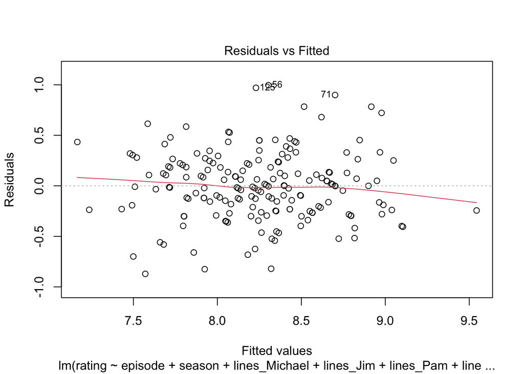

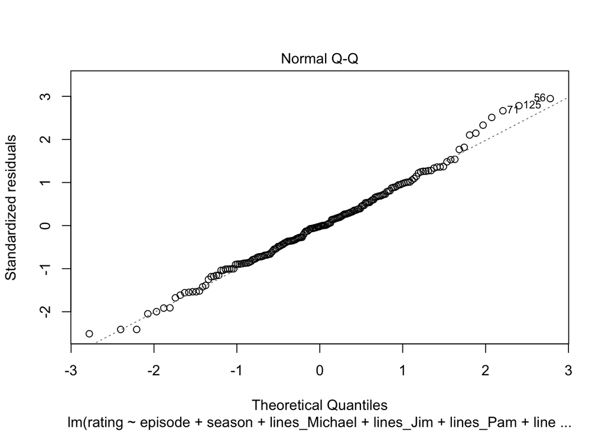

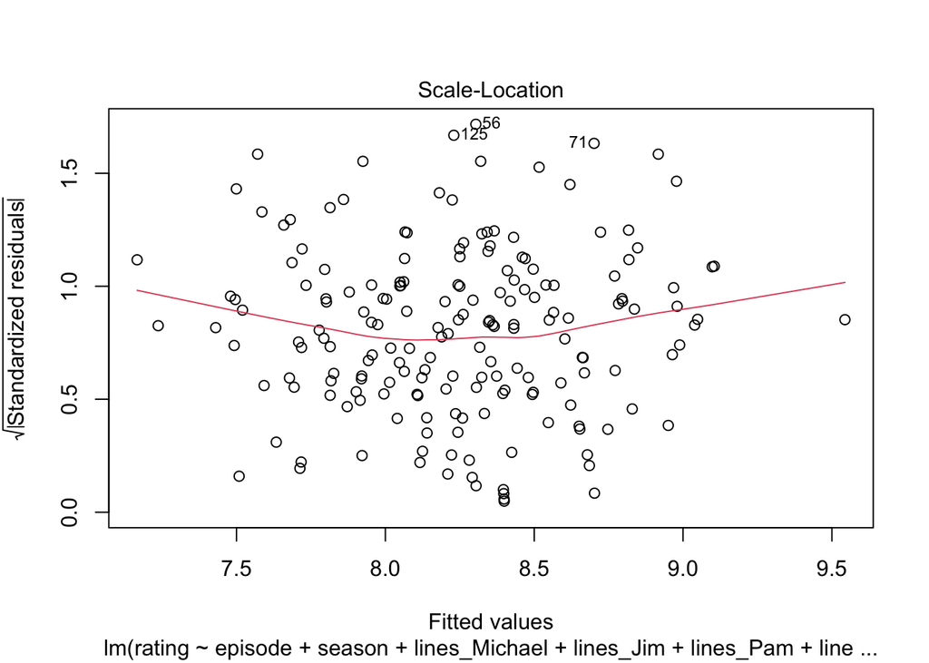

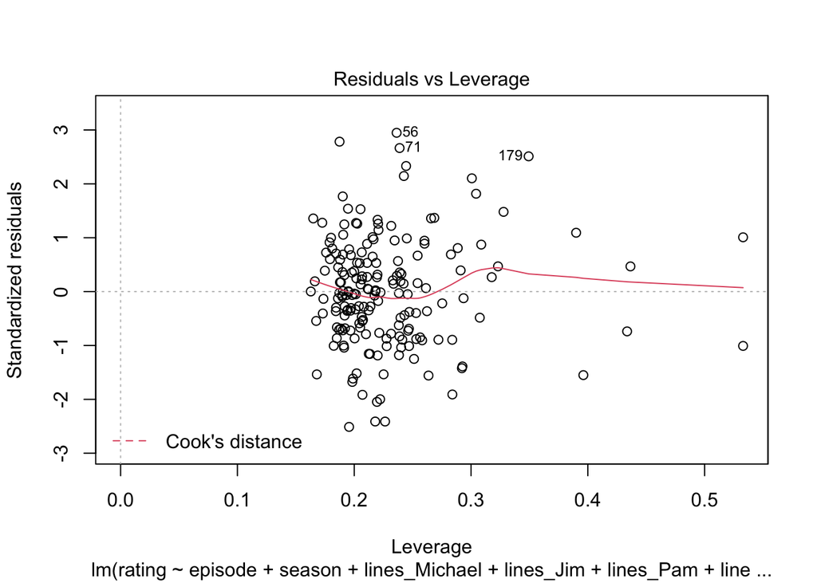

```r
plot(m1)
```

# Forward Selection

```r
# initial forward selection
bigger.model <- formula(lm(rating ~ season + episode + lines_Michael + lines_Jim + lines_Dwight + lines_Pam + lines_Nellie + s_Michael + s_Pam + s_Dwight + s_Jim + lines_Stanley + s_Stanley + lines_Nellie + s_Nellie + lines_Toby + s_Toby + lines_Gabe + s_Gabe + lines_Ryan + s_Ryan + lines_Karen + s_Karen + lines_Robert + s_Robert + lines_Andy + s_Andy, data_ratings))

v1.model <- step(m1, direction = "forward", scope = list(lower = m1, upper = bigger.model))
```

```
## Start:  AIC=-315.67
## rating ~ episode + season + lines_Michael + lines_Jim + lines_Pam +
##     lines_Dwight + s_Michael + s_Jim + s_Pam + s_Dwight
##
##                 Df Sum of Sq    RSS     AIC
## + lines_Nellie   1   1.63894 19.593 -328.61
## + lines_Stanley  1   0.99113 20.240 -322.56
## + s_Stanley      1   0.58201 20.649 -318.84
## + lines_Karen    1   0.56489 20.667 -318.68
## + s_Andy         1   0.54410 20.687 -318.50
## + s_Ryan         1   0.46673 20.765 -317.80
## + lines_Toby     1   0.29484 20.937 -316.27
## + s_Nellie       1   0.23452 20.997 -315.73
## + s_Gabe         1   0.23271 20.999 -315.72
## <none>                       21.232 -315.67
## + lines_Gabe     1   0.19364 21.038 -315.37
## + s_Toby         1   0.17538 21.056 -315.21
## + lines_Ryan     1   0.13056 21.101 -314.82
## + lines_Robert   1   0.06143 21.170 -314.21
## + lines_Andy     1   0.00712 21.224 -313.73
## + s_Karen        1   0.00114 21.230 -313.68
## + s_Robert       1   0.00001 21.232 -313.67
##
## Step:  AIC=-328.61
## rating ~ episode + season + lines_Michael + lines_Jim + lines_Pam +
##     lines_Dwight + s_Michael + s_Jim + s_Pam + s_Dwight + lines_Nellie
##
##                 Df Sum of Sq    RSS     AIC
## + lines_Stanley  1   0.96513 18.627 -336.01
## + lines_Karen    1   0.53832 19.054 -331.79
## + s_Andy         1   0.50512 19.087 -331.47
## + s_Ryan         1   0.40182 19.191 -330.47
## + s_Stanley      1   0.37880 19.214 -330.24
## + s_Gabe         1   0.30477 19.288 -329.53
## + lines_Toby     1   0.29671 19.296 -329.45
## <none>                       19.593 -328.61
## + s_Toby         1   0.17561 19.417 -328.29
## + s_Nellie       1   0.09142 19.501 -327.48
## + lines_Gabe     1   0.07423 19.518 -327.32
## + lines_Ryan     1   0.06515 19.527 -327.23
```

[output cut: 140 more lines]

```
## Step:  AIC=-350.09
## rating ~ episode + season + lines_Michael + lines_Jim + lines_Pam +
##     lines_Dwight + s_Michael + s_Jim + s_Pam + s_Dwight + lines_Nellie +
##     lines_Stanley + lines_Karen + s_Stanley + s_Ryan + lines_Toby +
##     s_Andy + s_Gabe + s_Toby
##
##                Df Sum of Sq    RSS     AIC
## <none>                      16.017 -350.09
## + lines_Ryan    1  0.147124 15.870 -349.81
## + s_Karen       1  0.131613 15.885 -349.62
## + lines_Andy    1  0.089045 15.928 -349.13
## + s_Nellie      1  0.074461 15.943 -348.96
## + lines_Gabe    1  0.013673 16.003 -348.25
## + lines_Robert  1  0.013411 16.004 -348.25
## + s_Robert      1  0.001163 16.016 -348.10
```

```r
interactions <- formula(lm(rating ~ season + episode + lines_Michael + lines_Jim + lines_Dwight + lines_Nellie + s_Michael + s_Pam + s_Dwight + lines_Stanley + s_Stanley + lines_Nellie + lines_Toby + s_Toby  + lines_Karen + s_Gabe + s_Andy + s_Ryan + season*lines_Michael + season*s_Michael + season*lines_Pam + season*lines_Jim + season*s_Jim + season*lines_Dwight + season*s_Dwight , data_ratings))

v2.model <- step(v1.model, direction = "forward", scope = list(lower = v1.model, upper = interactions))
```

```
## Start:  AIC=-350.09
## rating ~ episode + season + lines_Michael + lines_Jim + lines_Pam +
##     lines_Dwight + s_Michael + s_Jim + s_Pam + s_Dwight + lines_Nellie +
##     lines_Stanley + lines_Karen + s_Stanley + s_Ryan + lines_Toby +
##     s_Andy + s_Gabe + s_Toby
##
##                        Df Sum of Sq    RSS     AIC
## + season:s_Dwight       8   1.37261 14.644 -350.75
## <none>                              16.017 -350.09
## + season:lines_Michael  7   1.03522 14.982 -348.52
## + season:lines_Pam      8   1.18535 14.832 -348.39
## + season:s_Michael      7   0.91542 15.102 -347.04
## + season:lines_Jim      8   1.07564 14.941 -347.02
## + season:s_Jim          8   0.59017 15.427 -341.07
## + season:lines_Dwight   8   0.52781 15.489 -340.32
##
## Step:  AIC=-350.75
## rating ~ episode + season + lines_Michael + lines_Jim + lines_Pam +
##     lines_Dwight + s_Michael + s_Jim + s_Pam + s_Dwight + lines_Nellie +
##     lines_Stanley + lines_Karen + s_Stanley + s_Ryan + lines_Toby +
##     s_Andy + s_Gabe + s_Toby + season:s_Dwight
##
##                        Df Sum of Sq    RSS     AIC
## <none>                              14.644 -350.75
## + season:s_Michael      7   1.06170 13.583 -350.75
## + season:lines_Michael  7   1.04962 13.595 -350.59
## + season:lines_Pam      8   1.10988 13.534 -349.41
## + season:lines_Jim      8   0.99995 13.644 -347.91
## + season:lines_Dwight   8   0.87392 13.771 -346.20
## + season:s_Jim          8   0.67958 13.965 -343.59
```

```r
writers <- formula(lm(rating ~ season + episode + lines_Michael + lines_Jim + lines_Dwight + lines_Pam + lines_Nellie + s_Michael + s_Pam + s_Dwight + s_Jim + lines_Stanley + s_Stanley + lines_Nellie + lines_Toby + s_Ryan + lines_Karen + s_Toby + s_Gabe + s_Andy + season*s_Dwight + Mindy_Kaling + B.J._Novak + Paul_Lieberstein + Michael_Schur + episode, data_ratings))

final.model <- step(v2.model, direction = "forward", scope = list(lower = v2.model, upper = writers))
```

```
## Start:  AIC=-350.75
## rating ~ episode + season + lines_Michael + lines_Jim + lines_Pam +
##     lines_Dwight + s_Michael + s_Jim + s_Pam + s_Dwight + lines_Nellie +
##     lines_Stanley + lines_Karen + s_Stanley + s_Ryan + lines_Toby +
##     s_Andy + s_Gabe + s_Toby + season:s_Dwight
##
##                    Df Sum of Sq    RSS     AIC
## + Paul_Lieberstein  1  0.210397 14.434 -351.45
## <none>                          14.644 -350.75
## + Michael_Schur     1  0.153354 14.491 -350.71
## + B.J._Novak        1  0.069296 14.575 -349.64
## + Mindy_Kaling      1  0.017346 14.627 -348.97
##
## Step:  AIC=-351.45
## rating ~ episode + season + lines_Michael + lines_Jim + lines_Pam +
##     lines_Dwight + s_Michael + s_Jim + s_Pam + s_Dwight + lines_Nellie +
##     lines_Stanley + lines_Karen + s_Stanley + s_Ryan + lines_Toby +
##     s_Andy + s_Gabe + s_Toby + Paul_Lieberstein + season:s_Dwight
##
##                 Df Sum of Sq    RSS     AIC
## + Michael_Schur  1  0.199650 14.234 -352.04
## <none>                       14.434 -351.45
## + B.J._Novak     1  0.094997 14.339 -350.67
## + Mindy_Kaling   1  0.032557 14.401 -349.87
##
## Step:  AIC=-352.04
## rating ~ episode + season + lines_Michael + lines_Jim + lines_Pam +
##     lines_Dwight + s_Michael + s_Jim + s_Pam + s_Dwight + lines_Nellie +
##     lines_Stanley + lines_Karen + s_Stanley + s_Ryan + lines_Toby +
##     s_Andy + s_Gabe + s_Toby + Paul_Lieberstein + Michael_Schur +
##     season:s_Dwight
##
##                Df Sum of Sq    RSS     AIC
## <none>                      14.234 -352.04
## + B.J._Novak    1  0.118813 14.116 -351.60
## + Mindy_Kaling  1  0.054089 14.180 -350.74
```

```r
summary(final.model)
```

```
##
## Call:
## lm(formula = rating ~ episode + season + lines_Michael + lines_Jim +
##     lines_Pam + lines_Dwight + s_Michael + s_Jim + s_Pam + s_Dwight +
##     lines_Nellie + lines_Stanley + lines_Karen + s_Stanley +
##     s_Ryan + lines_Toby + s_Andy + s_Gabe + s_Toby + Paul_Lieberstein +
##     Michael_Schur + season:s_Dwight, data = data_ratings)
##
## Residuals:
##      Min       1Q   Median       3Q      Max
## -0.70287 -0.17800 -0.00999  0.21787  0.77087
##
## Coefficients:
##                   Estimate Std. Error t value Pr(>|t|)
## (Intercept)        7.43945    0.30412  24.462  < 2e-16 ***
## episode2          -0.24877    0.19910  -1.249 0.213858
## episode3          -0.41505    0.17848  -2.325 0.021684 *
## episode4          -0.10175    0.17951  -0.567 0.571845
## episode5          -0.37857    0.18576  -2.038 0.043700 *
## episode6          -0.25551    0.18248  -1.400 0.163958
## episode7          -0.26092    0.17900  -1.458 0.147485
## episode8          -0.27720    0.19012  -1.458 0.147377
## episode9          -0.07177    0.18137  -0.396 0.693006
## episode10          0.18875    0.18386   1.027 0.306645
## episode11         -0.09365    0.18322  -0.511 0.610187
## episode12          0.21361    0.18350   1.164 0.246626
## episode13         -0.21035    0.18077  -1.164 0.246835
## episode14         -0.28387    0.17512  -1.621 0.107573
## episode15         -0.03213    0.19428  -0.165 0.868906
## episode16         -0.08647    0.18108  -0.478 0.633834
## episode17         -0.03159    0.18379  -0.172 0.863827
## episode18         -0.24268    0.19436  -1.249 0.214175
## episode19         -0.02487    0.18990  -0.131 0.896022
## episode20          0.07699    0.19080   0.404 0.687264
## episode21          0.05174    0.18976   0.273 0.785579
## episode22          0.29491    0.18369   1.605 0.110964
## episode23          0.05563    0.21042   0.264 0.791929
## episode24          0.49520    0.20802   2.381 0.018821 *
## episode25          0.25180    0.24939   1.010 0.314642
## episode26         -0.24466    0.27983  -0.874 0.383634
```

[output cut: 28 more lines]

```
## Michael_Schur1     0.18488    0.14076   1.313 0.191472
## season2:s_Dwight   4.40940    5.06933   0.870 0.386093
## season3:s_Dwight   3.28219    5.02151   0.654 0.514573
## season4:s_Dwight   7.36031    5.17273   1.423 0.157295
## season5:s_Dwight   0.16430    5.04230   0.033 0.974059
## season6:s_Dwight   3.53615    5.01039   0.706 0.481669
## season7:s_Dwight   5.00736    5.09200   0.983 0.327351
## season8:s_Dwight   4.54950    4.98892   0.912 0.363595
## season9:s_Dwight   7.45124    5.00857   1.488 0.139390
## ---
## Signif. codes:  0 '***' 0.001 '**' 0.01 '*' 0.05 '.' 0.1 ' ' 1
##
## Residual standard error: 0.3402 on 123 degrees of freedom
## Multiple R-squared:  0.7314, Adjusted R-squared:  0.5959
## F-statistic: 5.401 on 62 and 123 DF,  p-value: 9.767e-16
```

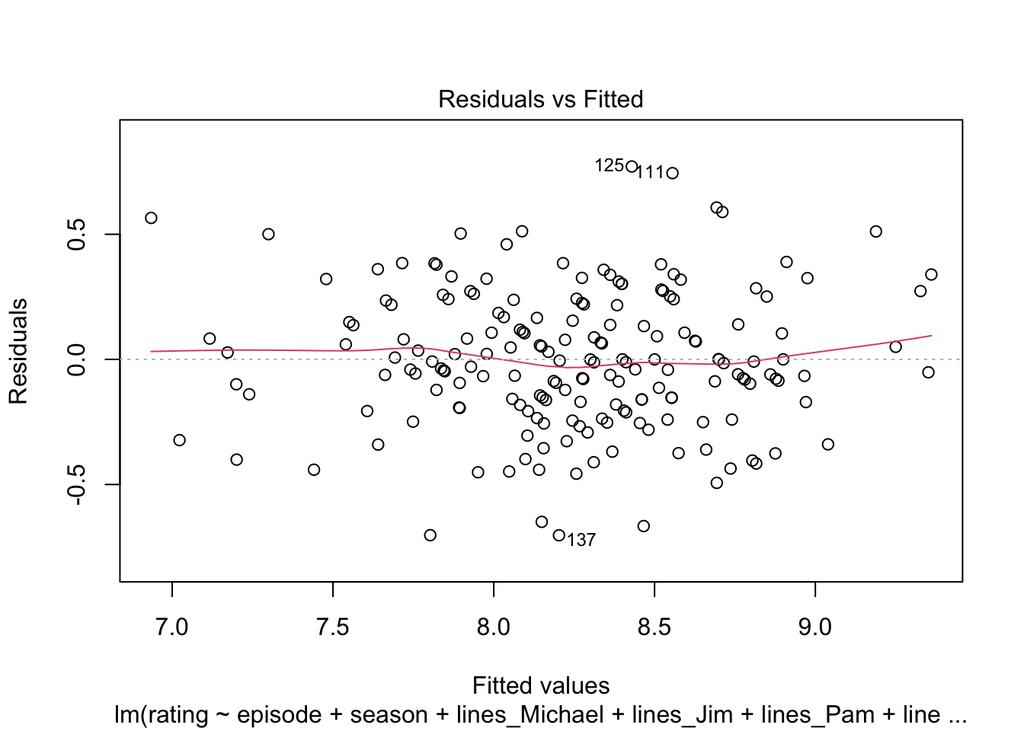

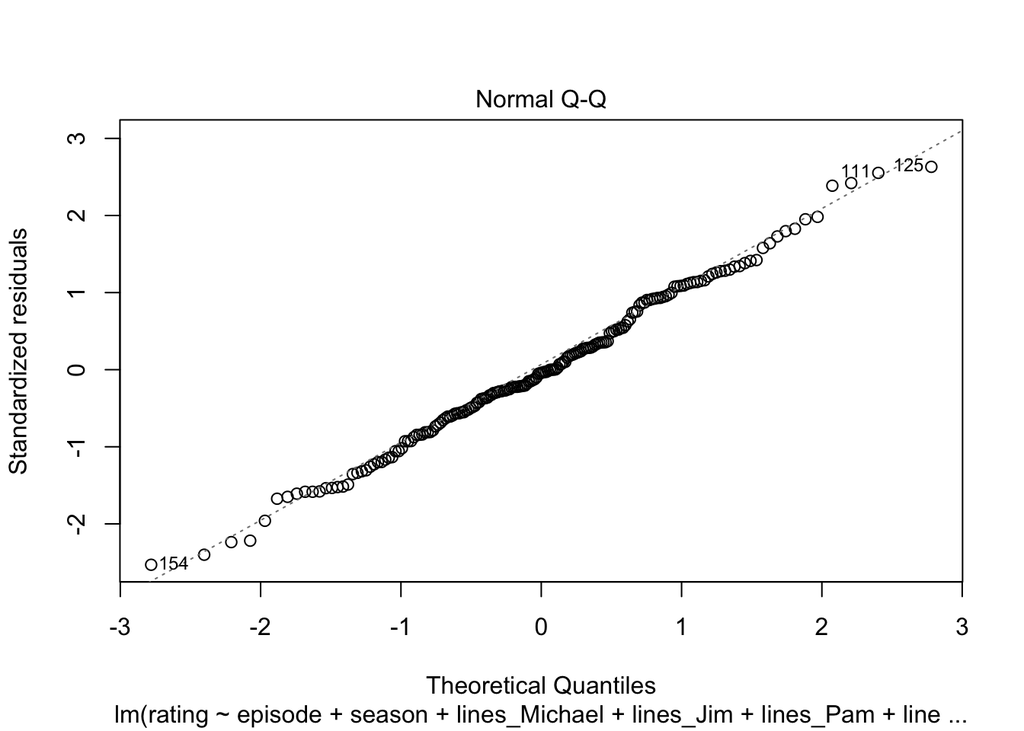

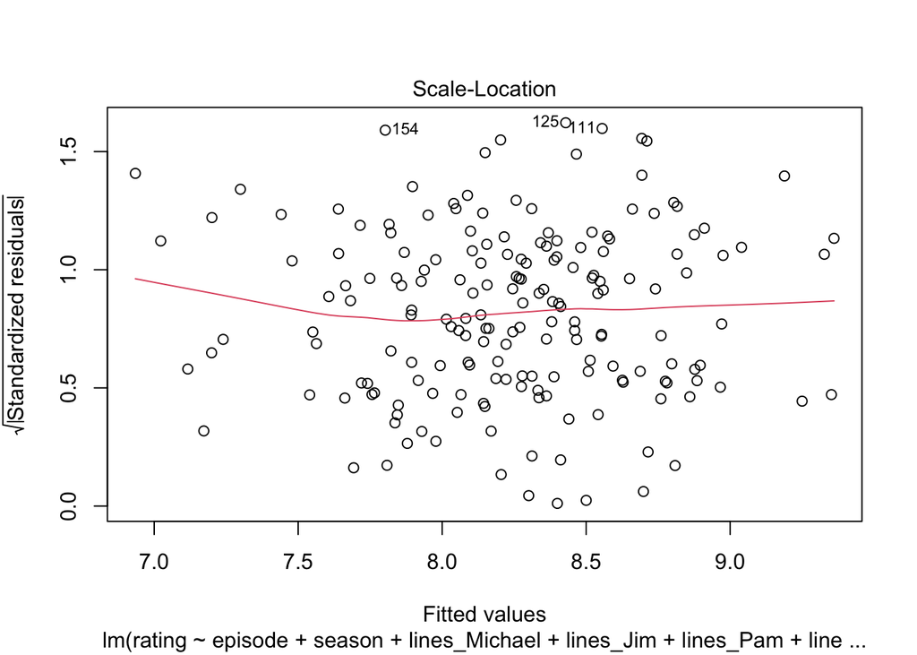

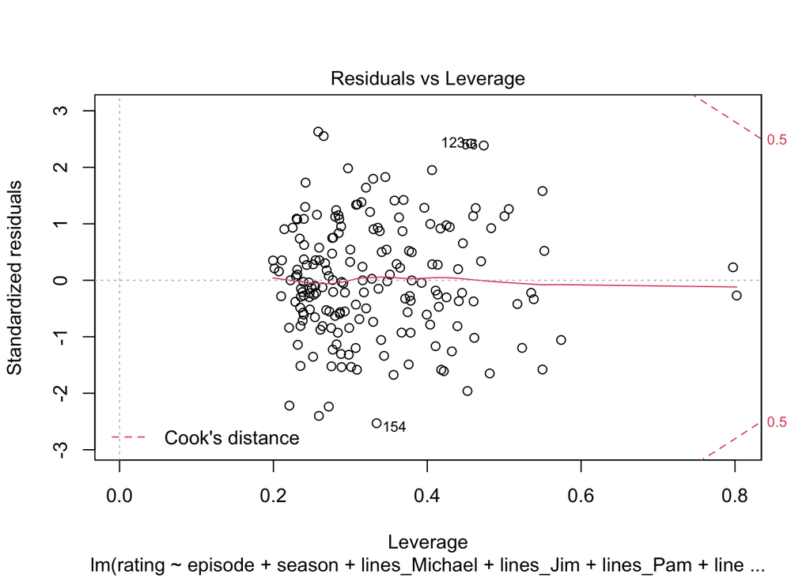

```r
plot(final.model)
```

# Cross Validation

```r
IDs = seq(1,186)

# 80 - 20 test split
test_size = 5

MSEs = c()
MAEs = c()

set.seed(0)
for(i in 1:test_size){
  set.seed(1)
  train_IDs = sample(IDs, 148)
  train = data_ratings[train_IDs,]
  test = data_ratings[-train_IDs,]

  our_model = lm(rating ~ season + lines_Michael + lines_Jim + lines_Pam + lines_Dwight +
    s_Michael + s_Jim + s_Pam + s_Dwight + lines_Nellie + lines_Stanley +
    s_Stanley + s_Andy + lines_Toby + s_Gabe + s_Toby + season*s_Michael, data=train)

  predictions = predict(our_model, test)
  residuals = predictions - test$rating
  MSE = mean(residuals^2)
  MAE = abs(residuals)
  MSEs = c(MSEs, MSE)
  MAEs = c(MAEs, MAE)
}
print(mean(MSEs))
```

```
## [1] 0.1440502
```

```r
print(mean(MAEs))
```

```
## [1] 0.3089315
```

# Code below was not discussed in this submission

```r
# complete forward selection
#full.model <- formula(lm(rating ~ season + lines_Michael + lines_Jim + lines_Dwight + lines_Nellie + s_Michael + s_Pam + s_Dwight + s_Stanley + episode + lines_Angela + lines_Jan + lines_Kevin + lines_Oscar + lines_Phyllis + lines_Roy + lines_Ryan + lines_Stanley + lines_Kelly + lines_Toby + lines_Meredith + lines_Darryl + lines_Creed + lines_Andy + lines_Karen + lines_Holly + lines_Erin + lines_Gabe + s_Angela + s_Jan + s_Kevin + s_Oscar + s_Phyllis + s_Roy + s_Ryan + s_Kelly + s_Toby + s_Meredith + s_Darryl + s_Creed + s_Andy + s_Karen + s_Holly + s_Erin + s_Gabe + s_Nellie + Mindy_Kaling + Paul_Lieberstein + B.J._Novak + Michael_Schur + season*lines_Michael + season*s_Michael + season*lines_Pam + season*s_Pam + season*lines_Jim + season*s_Jim + season*lines_Dwight + season*s_Dwight + season*s_Stanley, data_ratings))

#fwd.model <- step(v2.model, direction = 'forward', scope = list(lower = final.model, upper = full.model))
```

```r
#summary(fwd.model)
```